# MLAssignment02

```python
from datetime import timedelta, datetime
import numpy as np
import  pandas as pd
import sklearn
from matplotlib.pyplot import MultipleLocator
from matplotlib import pyplot as plt
from statsmodels.tsa.seasonal import seasonal_decompose
from sklearn.ensemble import  RandomForestRegressor
from sklearn.linear_model import  LinearRegression
from sklearn.model_selection import train_test_split
!pip install mlxtend
from mlxtend.feature_selection import SequentialFeatureSelector
```

## Task 1

1.1 Load DataSet

```python
df = pd.read_csv('metro_traffic_15_19.csv')
# There are duplicate data in the data set, so here is a cleanup
df = df.drop_duplicates()
df.head(5)
```

|  | date_time | rain_1h | snow_1h | temp | clouds_all | traffic_volume |
| --- | --- | --- | --- | --- | --- | --- |
| 0 | 2015-07-01 00:00:00 | 0.0 | 0.0 | 289.20 | 1 | 737 |
| 1 | 2015-07-01 01:00:00 | 0.0 | 0.0 | 289.40 | 1 | 444 |
| 2 | 2015-07-01 02:00:00 | 0.0 | 0.0 | 289.19 | 1 | 347 |
| 3 | 2015-07-01 03:00:00 | 0.3 | 0.0 | 288.74 | 1 | 356 |
| 4 | 2015-07-01 04:00:00 | 0.0 | 0.0 | 288.07 | 1 | 936 |

```python
# Use the date as the index of the data set to facilitate later extraction of data within the specified date.
df = df.set_index('date_time')
df.index = pd.to_datetime(df.index)
ts = df['traffic_volume']
df.head(5)
```

| date_time | rain_1h | snow_1h | temp | clouds_all | traffic_volume |
| --- | --- | --- | --- | --- | --- |
| 2015-07-01 00:00:00 | 0.0 | 0.0 | 289.20 | 1 | 737 |
| 2015-07-01 01:00:00 | 0.0 | 0.0 | 289.40 | 1 | 444 |
| 2015-07-01 02:00:00 | 0.0 | 0.0 | 289.19 | 1 | 347 |
| 2015-07-01 03:00:00 | 0.3 | 0.0 | 288.74 | 1 | 356 |
| 2015-07-01 04:00:00 | 0.0 | 0.0 | 288.07 | 1 | 936 |

1.2 Periodicity

The periodicity of the data is analyzed according to different time periods to graph.

Analysis of the general trend from 2015-2018.

```python
# Add up the data for each month
t_all = df.resample('M').sum()['2015-7':'2018-12']
t_all.head(5)
```

| date_time | rain_1h | snow_1h | temp | clouds_all | traffic_volume |
| --- | --- | --- | --- | --- | --- |
| 2015-07-31 | 227.79 | 0.0 | 218547.990 | 16794 | 2384492 |
| 2015-08-31 | 181.01 | 0.0 | 214269.260 | 21913 | 2453232 |
| 2015-09-30 | 119.57 | 0.0 | 190536.430 | 18064 | 2183277 |
| 2015-10-31 | 16.75 | 0.0 | 138444.810 | 15167 | 1608614 |
| 2015-11-30 | 0.00 | 0.0 | 110031.204 | 17021 | 1233971 |

Overall Trend Chart 2015-2018

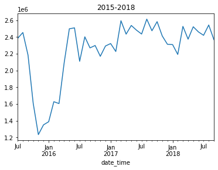

```python
t_all['traffic_volume'].plot()
plt.title("2015-2018")
```

In general, the plot does not show a very clear cyclical trend.

Next, pick a random month of the year to analyze

```python
# Select each day of September in each year to analyze
t_2015 = df.resample('D').sum()['2015-9':'2015-9-30']
t_2016 = df.resample('D').sum()['2016-9':'2016-9-30']
t_2017 = df.resample('D').sum()['2017-9':'2017-9-30']
t_2018 = df.resample('D').sum()['2018-9':'2018-9-30']

t_2015.head(5)
```

| date_time | rain_1h | snow_1h | temp | clouds_all | traffic_volume |
| --- | --- | --- | --- | --- | --- |
| 2015-09-01 | 0.30 | 0.0 | 2989.56 | 103 | 42220 |
| 2015-09-02 | 4.83 | 0.0 | 5914.75 | 1047 | 86892 |
| 2015-09-03 | 0.30 | 0.0 | 7119.78 | 905 | 94326 |
| 2015-09-04 | 0.00 | 0.0 | 7168.85 | 273 | 91073 |
| 2015-09-05 | 4.47 | 0.0 | 7191.86 | 437 | 67099 |

Plot the corresponding diagrams respectively.

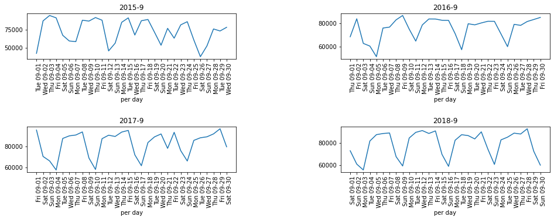

```python
fig = plt.figure(figsize=(16,5))

fig1 = plt.subplot(2,2,1)
plt.subplots_adjust(wspace =0.5, hspace =1.5)
plt.plot([x for x in range(1,len(t_2015['traffic_volume'])+1)] ,t_2015['traffic_volume'])
# Display by day of the week, month and day
xticks = pd.date_range(start = t_2015.index.min(), end =t_2015.index.max() , freq ='D')
plt.xticks(range(1,len(t_2015)+1,1),xticks.strftime(('%a %m-%d')), rotation=90,ha='left')
plt.title("2015-9")
plt.xlabel('per day')


fig2 = plt.subplot(2,2,2)
plt.plot([x for x in range(1,len(t_2016['traffic_volume'])+1)],t_2016['traffic_volume'])
# Display by day of the week, month and day
xticks = pd.date_range(start = t_2016.index.min(), end =t_2016.index.max() , freq ='D')
plt.xticks(range(1,len(t_2016)+1,1),xticks.strftime(('%a %m-%d')), rotation=90,ha='left')
plt.title("2016-9")
plt.xlabel('per day')

fig3 = plt.subplot(2, 2, 3)
plt.plot([x for x in range(1,len(t_2017['traffic_volume'])+1)],t_2017['traffic_volume'])
# Display by day of the week, month and day
xticks = pd.date_range(start = t_2017.index.min(), end =t_2017.index.max() , freq ='D')
plt.xticks(range(1,len(t_2017)+1,1),xticks.strftime(('%a %m-%d')), rotation=90,ha='left')
plt.title("2017-9")
plt.xlabel('per day')

fig4 = plt.subplot(2, 2, 4)
plt.plot([x for x in range(1,len(t_2018['traffic_volume'])+1)],t_2018['traffic_volume'])
# Display by day of the week, month and day
xticks = pd.date_range(start = t_2018.index.min(), end =t_2018.index.max() , freq ='D')
plt.xticks(range(1,len(t_2018)+1,1),xticks.strftime(('%a %m-%d')), rotation=90,ha='left')
plt.title("2018-9")
plt.xlabel('per day')
```

Among all the September months, there are 4-5 consecutive ups and downs that can show a pattern every day. The total traffic_volume for September fluctuates roughly from 80,000 to 60,000. It will drop on weekends reaching its lowest point on Sunday and rises during working days.There is a clear cycle of seven-day basis.

These ups and downs seem to correlate with whether it's a weekday, and whether it's a weekend.

Analyzing a day in the middle of a working day in September of each year.

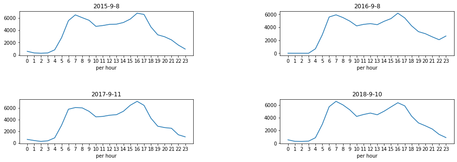

```python
# Working day

fig = plt.figure(figsize=(16,5))
plt.subplots_adjust(wspace =0.5, hspace =1)
fig1 = plt.subplot(2,2,1)
plt.plot([x for x in range(0,len(ts['2015-9-8':'2015-9-8']))],ts['2015-9-8':'2015-9-8'])
# Display by hour
plt.xticks(range(0,len(ts['2015-9-8':'2015-9-8']),1))
plt.title("2015-9-8")
plt.xlabel('per hour')

fig2 = plt.subplot(2,2,2)
plt.plot([x for x in range(0,len(ts['2016-9-8':'2016-9-8']))],ts['2016-9-8':'2016-9-8'])
# Display by hour
plt.xticks(range(0,len(ts['2016-9-8':'2016-9-8']),1))
plt.title("2016-9-8")
plt.xlabel('per hour')

fig3 = plt.subplot(2, 2, 3)
plt.subplot(2, 2, 3)
plt.plot([x for x in range(0,len(ts['2017-9-11':'2017-9-11']))],ts['2017-9-11':'2017-9-11'])
# Display by hour
plt.xticks(range(0,len(ts['2017-9-11':'2017-9-11']),1))
plt.title("2017-9-11")
plt.xlabel('per hour')

fig4 = plt.subplot(2, 2, 4)
plt.subplot(2, 2, 4)
plt.plot([x for x in range(0,len(ts['2018-9-10':'2018-9-10']))],ts['2018-9-10':'2018-9-10'])
# Display by hour
plt.xticks(range(0,len(ts['2018-9-10':'2018-9-10']),1))
plt.title("2018-9-10")
plt.xlabel('per hour')
```

The graphs also show periodic fluctuations during each hour of the working day. The number decreases to a minimum between 11:00 pm and 4:00 am. It reaches its highest value after 4:00 am to 7:00 am. From 7:00 am to 12:00 am, it dropped more. Then it reaches its highest point at 4 pm, after which it slowly decreases.

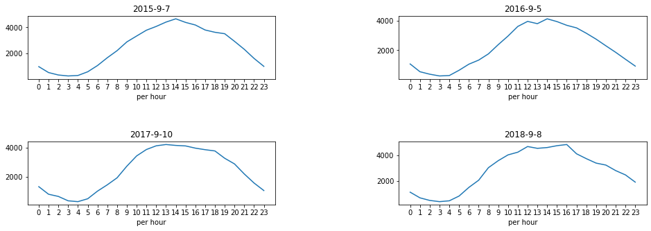

```python
# Weekends
fig = plt.figure(figsize=(16,5))
plt.subplots_adjust(wspace =0.5, hspace =1)

plt.subplots_adjust(left=None, bottom=None, right=None, top=None, wspace=0.5, hspace=1)
plt.subplot(2, 2, 1)
plt.plot([x for x in range(0,len(ts['2015-9-7':'2015-9-7']))],ts['2015-9-7':'2015-9-7'])
# Display by hour
plt.xticks(range(0,len(ts['2015-9-7':'2015-9-7']),1))
plt.title("2015-9-7")
plt.xlabel('per hour')

plt.subplot(2, 2, 2)
plt.plot([x for x in range(0,len(ts['2016-9-5':'2016-9-5']))],ts['2016-9-5':'2016-9-5'])
# Display by hour
plt.xticks(range(0,len(ts['2016-9-5':'2016-9-5']),1))
plt.title("2016-9-5")
plt.xlabel('per hour')

plt.subplot(2, 2, 3)
plt.plot([x for x in range(0,len(ts['2017-9-10':'2017-9-10']))],ts['2017-9-10':'2017-9-10'])
# Display by hour
plt.xticks(range(0,len(ts['2017-9-10':'2017-9-10']),1))
plt.title("2017-9-10")
plt.xlabel('per hour')

plt.subplot(2, 2, 4)
plt.plot([x for x in range(0,len(ts['2018-9-8':'2018-9-8']))],ts['2018-9-8':'2018-9-8'])
# Display by hour
plt.xticks(range(0,len(ts['2018-9-8':'2018-9-8']),1))
plt.title("2018-9-8")
plt.xlabel('per hour')
```

Holistic analysis of a full month of September 2015.

```python
# The daily Traffic_volume is added up
ts_month = ts.resample('D').sum()['2015-9':'2015-9-30']
ts_month.head(5)
```

```
date_time
2015-09-01    42220
2015-09-02    86892
2015-09-03    94326
2015-09-04    91073
2015-09-05    67099
Freq: D, Name: traffic_volume, dtype: int64
```

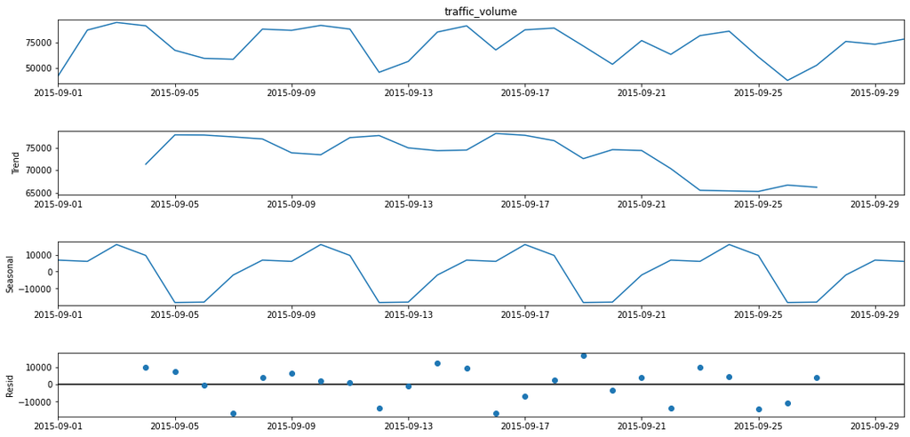

```python
decomposition = seasonal_decompose(ts_month ,period=7)
fig = decomposition.plot()
fig.set_size_inches(18,8)
plt.show()
```

Seasonal: Focus on the cyclical part, as 7 days is 1 cycle. The lowest values of Traffic_volume are reached on days 6 and 7 of the cycle, i.e., Saturday and Sunday(Sept. 5th, Sept. 13th,etc).

## Task 2

2.1 Features

```python
# Extract out hour day month features from index
df['hour'] = df.index.hour
df['day'] = df.index.day
df['month'] = df.index.month
df.head(5)
```

| date_time | rain_1h | snow_1h | temp | clouds_all | traffic_volume | hour | day | month |
| --- | --- | --- | --- | --- | --- | --- | --- | --- |
| 2015-07-01 00:00:00 | 0.0 | 0.0 | 289.20 | 1 | 737 | 0 | 1 | 7 |
| 2015-07-01 01:00:00 | 0.0 | 0.0 | 289.40 | 1 | 444 | 1 | 1 | 7 |
| 2015-07-01 02:00:00 | 0.0 | 0.0 | 289.19 | 1 | 347 | 2 | 1 | 7 |
| 2015-07-01 03:00:00 | 0.3 | 0.0 | 288.74 | 1 | 356 | 3 | 1 | 7 |
| 2015-07-01 04:00:00 | 0.0 | 0.0 | 288.07 | 1 | 936 | 4 | 1 | 7 |

Fetch all features in the data

```python
features = pd.DataFrame({
'rain_1h' : df.rain_1h,
'snow_1h' : df.snow_1h,
'temp'    :df.temp,
'clouds_all' : df.clouds_all,
'month' : df.month,
'day' : df.day,
'hour' : df.hour,
})
# Take out the target value traffic_volume
target = df.traffic_volume
features.head(5)
```

| date_time | rain_1h | snow_1h | temp | clouds_all | month | day | hour |
| --- | --- | --- | --- | --- | --- | --- | --- |
| 2015-07-01 00:00:00 | 0.0 | 0.0 | 289.20 | 1 | 7 | 1 | 0 |
| 2015-07-01 01:00:00 | 0.0 | 0.0 | 289.40 | 1 | 7 | 1 | 1 |
| 2015-07-01 02:00:00 | 0.0 | 0.0 | 289.19 | 1 | 7 | 1 | 2 |
| 2015-07-01 03:00:00 | 0.3 | 0.0 | 288.74 | 1 | 7 | 1 | 3 |
| 2015-07-01 04:00:00 | 0.0 | 0.0 | 288.07 | 1 | 7 | 1 | 4 |

Select two weeks in September 2015 as data and then subdivided.

```python
features_set = features['2015-9-7':'2015-9-22']
features_set.head(5)
```

| date_time | rain_1h | snow_1h | temp | clouds_all | month | day | hour |
| --- | --- | --- | --- | --- | --- | --- | --- |
| 2015-09-07 00:00:00 | 0.0 | 0.0 | 295.02 | 90 | 9 | 7 | 0 |
| 2015-09-07 01:00:00 | 0.0 | 0.0 | 294.36 | 1 | 9 | 7 | 1 |
| 2015-09-07 02:00:00 | 0.0 | 0.0 | 294.21 | 1 | 9 | 7 | 2 |
| 2015-09-07 03:00:00 | 0.3 | 0.0 | 293.50 | 1 | 9 | 7 | 3 |
| 2015-09-07 04:00:00 | 0.3 | 0.0 | 293.14 | 40 | 9 | 7 | 4 |

```python
target_set = target['2015-9-7':'2015-9-22']
target_set.head(5)
```

```
date_time
2015-09-07 00:00:00    973
2015-09-07 01:00:00    517
2015-09-07 02:00:00    329
2015-09-07 03:00:00    255
2015-09-07 04:00:00    291
Name: traffic_volume, dtype: int64
```

Construct a function to perform regression prediction

```python
def eval_on_features(features, target, regresor):
    # Because it is a time series, the order of the data in time cannot be disturbed.
    X_train, X_test, y_train, y_test = train_test_split(features, target, test_size=0.33, shuffle = False)

    xticks = pd.date_range(start = features.index.min(), end =features.index.max() , freq ='D')
    regresor.fit(X_train,y_train)
    #
    print('Test-set R^2:{:.2f}'.format(regresor.score(X_test,y_test)))

    y_pre = regresor.predict(X_test)
    y_pre_trian = regresor.predict(X_train)
    plt.figure(figsize=(8,5))

    # The data is presented in hours, so every 24 hours is set to a day and the subscripts are displayed by week, month, and day.
    plt.xticks(range(0,len(features),24),xticks.strftime(('%a %m-%d')), rotation=90,ha='left')

    plt.plot(range(len(X_train)),y_train,label = 'train')
    plt.plot(range(len(X_train),len(y_test)+len(X_train)),y_test,'-',label = 'test')
    plt.plot(range(len(X_train)), y_pre_trian,'--',label = 'predction trian')

    plt.plot(range(len(X_train),len(y_test)+len(X_train)),y_pre,'--',label='prediction test')

    plt.legend(loc=(1.01,0))
    plt.ylabel("traffic_volume")
    plt.show()
```

```
LinearRegression
Test-set R^2:0.25
```

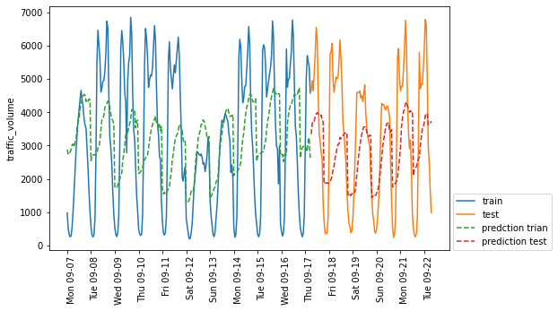

```
RandomForestRegressor
Test-set R^2:0.85
```

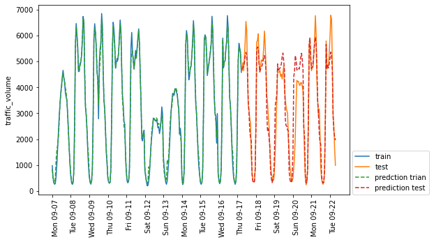

```python
print('LinearRegression')
# Calling LinearRegression
eval_on_features(features_set,target_set,LinearRegression())
print('RandomForestRegressor')
# Calling RandomForestRegression
regressor = RandomForestRegressor(n_estimators=100,random_state=0)
eval_on_features(features_set,target_set,regressor)
```

The first LinearRegression model, which was a poor fit to the data.

The second RandomForest model, which fits the data better.It is impossible to explain, knowing which variable is most related to the number of traffic_volume, which cannot be seen through the plot.

## Task 3

3.1 Encoding Cyclical Features

```python
# Introduction of periodic signal retesting
df['hour_sin'] = np.sin(2 * np.pi * df['hour']/24.0)
df['hour_cos'] = np.cos(2 * np.pi * df['hour']/24.0)
df['day_sin'] = np.sin(2 * np.pi * df['day']/24.0)
df['day_cos'] = np.cos(2 * np.pi * df['day']/24.0)
df['month_sin'] = np.sin(2 * np.pi * df['month']/24.0)
df['month_cos'] = np.cos(2 * np.pi * df['month']/24.0)
df.head(5)
```

| date_time | rain_1h | snow_1h | temp | clouds_all | traffic_volume | hour | day | month | hour_sin | hour_cos | day_sin | day_cos | month_sin | month_cos |
| --- | --- | --- | --- | --- | --- | --- | --- | --- | --- | --- | --- | --- | --- | --- |
| 2015-07-01 00:00:00 | 0.0 | 0.0 | 289.20 | 1 | 737 | 0 | 1 | 7 | 0.000000 | 1.000000 | 0.258819 | 0.965926 | 0.965926 | -0.258819 |
| 2015-07-01 01:00:00 | 0.0 | 0.0 | 289.40 | 1 | 444 | 1 | 1 | 7 | 0.258819 | 0.965926 | 0.258819 | 0.965926 | 0.965926 | -0.258819 |
| 2015-07-01 02:00:00 | 0.0 | 0.0 | 289.19 | 1 | 347 | 2 | 1 | 7 | 0.500000 | 0.866025 | 0.258819 | 0.965926 | 0.965926 | -0.258819 |
| 2015-07-01 03:00:00 | 0.3 | 0.0 | 288.74 | 1 | 356 | 3 | 1 | 7 | 0.707107 | 0.707107 | 0.258819 | 0.965926 | 0.965926 | -0.258819 |
| 2015-07-01 04:00:00 | 0.0 | 0.0 | 288.07 | 1 | 936 | 4 | 1 | 7 | 0.866025 | 0.500000 | 0.258819 | 0.965926 | 0.965926 | -0.258819 |

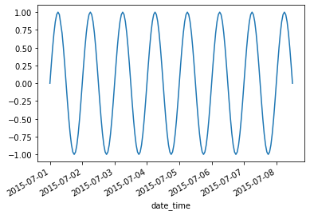

```python
df[0:180]['hour_sin'].plot()
```

We can see from the graph that it is cyclical.

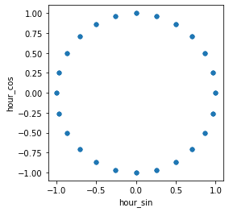

```python
df[0:180].plot.scatter('hour_sin', 'hour_cos').set_aspect('equal')
```

Periodic data is encoded as a cycle.

Take out features

```python
# Extract features
features_Cyc = pd.DataFrame({
'rain_1h' : df.rain_1h,
'snow_1h' : df.snow_1h,
'temp'    :df.temp,
'clouds_all' : df.clouds_all,
'month_sin' : df.month_sin,
'month_cos' : df.month_cos,
'day_sin' : df.day_sin,
'day_cos' : df.day_cos,
'hour_sin' : df.hour_sin,
'hour_cos' : df.hour_cos,
})
features_Cyc.head(5)
```

| date_time | rain_1h | snow_1h | temp | clouds_all | month_sin | month_cos | day_sin | day_cos | hour_sin | hour_cos |
| --- | --- | --- | --- | --- | --- | --- | --- | --- | --- | --- |
| 2015-07-01 00:00:00 | 0.0 | 0.0 | 289.20 | 1 | 0.965926 | -0.258819 | 0.258819 | 0.965926 | 0.000000 | 1.000000 |
| 2015-07-01 01:00:00 | 0.0 | 0.0 | 289.40 | 1 | 0.965926 | -0.258819 | 0.258819 | 0.965926 | 0.258819 | 0.965926 |
| 2015-07-01 02:00:00 | 0.0 | 0.0 | 289.19 | 1 | 0.965926 | -0.258819 | 0.258819 | 0.965926 | 0.500000 | 0.866025 |
| 2015-07-01 03:00:00 | 0.3 | 0.0 | 288.74 | 1 | 0.965926 | -0.258819 | 0.258819 | 0.965926 | 0.707107 | 0.707107 |
| 2015-07-01 04:00:00 | 0.0 | 0.0 | 288.07 | 1 | 0.965926 | -0.258819 | 0.258819 | 0.965926 | 0.866025 | 0.500000 |

Select two weeks in September 2015 as data and then subdivided.

```python
features_set_Cyc = features_Cyc['2015-9-7':'2015-9-22']
# features_set_Cyc = features_Cyc['2015-7-4':'2015-7-13']
features_set_Cyc.head(5)
```

| date_time | rain_1h | snow_1h | temp | clouds_all | month_sin | month_cos | day_sin | day_cos | hour_sin | hour_cos |
| --- | --- | --- | --- | --- | --- | --- | --- | --- | --- | --- |
| 2015-09-07 00:00:00 | 0.0 | 0.0 | 295.02 | 90 | 0.707107 | -0.707107 | 0.965926 | -0.258819 | 0.000000 | 1.000000 |
| 2015-09-07 01:00:00 | 0.0 | 0.0 | 294.36 | 1 | 0.707107 | -0.707107 | 0.965926 | -0.258819 | 0.258819 | 0.965926 |
| 2015-09-07 02:00:00 | 0.0 | 0.0 | 294.21 | 1 | 0.707107 | -0.707107 | 0.965926 | -0.258819 | 0.500000 | 0.866025 |
| 2015-09-07 03:00:00 | 0.3 | 0.0 | 293.50 | 1 | 0.707107 | -0.707107 | 0.965926 | -0.258819 | 0.707107 | 0.707107 |
| 2015-09-07 04:00:00 | 0.3 | 0.0 | 293.14 | 40 | 0.707107 | -0.707107 | 0.965926 | -0.258819 | 0.866025 | 0.500000 |

```
LinearRegression
Test-set R^2:0.62
```

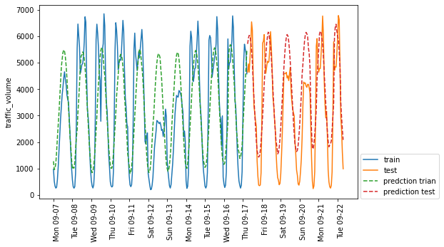

```
RandomForestRegressor
Test-set R^2:0.76
```

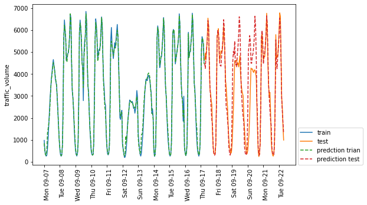

```python
print('LinearRegression')
# Calling LinearRegression
eval_on_features(features_set_Cyc,target_set,LinearRegression())
print('RandomForestRegressor')
# Calling RandomForestRegression
eval_on_features(features_set_Cyc,target_set,regressor)
```

With the introduction of periodic signals, the fit of the linear regression is significantly increased. However, the fit of the random forest was slightly reduced.

## Task 4

The features of the introduced periodic signal with a better fit above are taken.

```python
features_set_Cyc.head(5)
```

| date_time | rain_1h | snow_1h | temp | clouds_all | month_sin | month_cos | day_sin | day_cos | hour_sin | hour_cos |
| --- | --- | --- | --- | --- | --- | --- | --- | --- | --- | --- |
| 2015-09-07 00:00:00 | 0.0 | 0.0 | 295.02 | 90 | 0.707107 | -0.707107 | 0.965926 | -0.258819 | 0.000000 | 1.000000 |
| 2015-09-07 01:00:00 | 0.0 | 0.0 | 294.36 | 1 | 0.707107 | -0.707107 | 0.965926 | -0.258819 | 0.258819 | 0.965926 |
| 2015-09-07 02:00:00 | 0.0 | 0.0 | 294.21 | 1 | 0.707107 | -0.707107 | 0.965926 | -0.258819 | 0.500000 | 0.866025 |
| 2015-09-07 03:00:00 | 0.3 | 0.0 | 293.50 | 1 | 0.707107 | -0.707107 | 0.965926 | -0.258819 | 0.707107 | 0.707107 |
| 2015-09-07 04:00:00 | 0.3 | 0.0 | 293.14 | 40 | 0.707107 | -0.707107 | 0.965926 | -0.258819 | 0.866025 | 0.500000 |

Call wrapper to do feature selection

```python
def Feature_select(k_feaures,features,target,regressor):
    feature_select = SequentialFeatureSelector(regressor,
                                           k_features=k_feaures,
                                           forward=True,
                                           floating=False,
                                           scoring='r2',
                                           cv=5)
    feature_select.fit(features,target)
    return list(feature_select.k_feature_names_)
```

Find the best three features

```python
# LinearRegression
features_L_3 = Feature_select(3,features_set_Cyc,target_set,LinearRegression())
features_L_3
```

```
['snow_1h', 'hour_sin', 'hour_cos']
```

```python
# RandomForestRegression
features_R_3 =Feature_select(3,features_set_Cyc,target_set,regressor)
features_R_3
```

```
['snow_1h', 'hour_sin', 'hour_cos']
```

Testing and scoring

```
LinearRegression
Test-set R^2:0.72
```

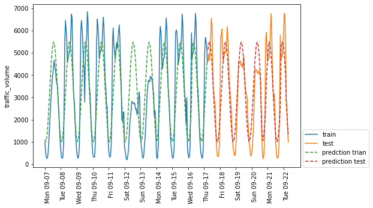

```
RandomForestRegressor
Test-set R^2:0.80
```

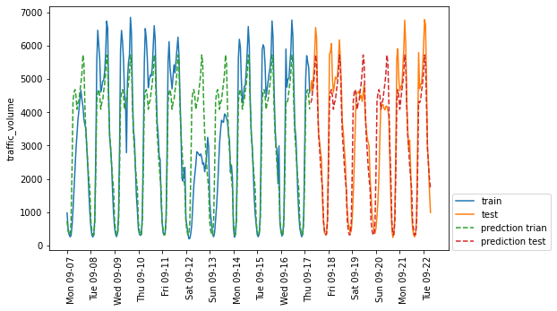

```python
print('LinearRegression')
fl_3 = pd.DataFrame(features_set_Cyc,  columns=features_L_3)
eval_on_features(fl_3,target_set,LinearRegression())
print('RandomForestRegressor')
fr_3 = pd.DataFrame(features_set_Cyc,  columns=features_R_3)
eval_on_features(fr_3,target_set,regressor)
```

Both have been upgraded a little.

```python
# Find the best five features
features_L_5 = Feature_select(5,features_set_Cyc,target_set,LinearRegression())
features_L_5
```

```
['snow_1h', 'month_sin', 'month_cos', 'hour_sin', 'hour_cos']
```

```python
# Find the best five features
features_R_5 =Feature_select(5,features_set_Cyc,target_set,regressor)
features_R_5
```

```
['snow_1h', 'month_sin', 'month_cos', 'hour_sin', 'hour_cos']
```

```
LinearRegression
Test-set R^2:0.72
```

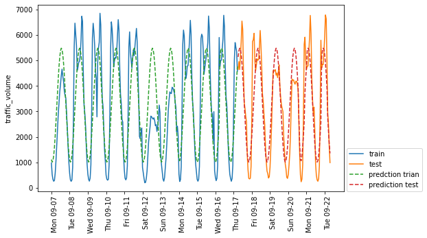

```
RandomForestRegressor
Test-set R^2:0.80
```

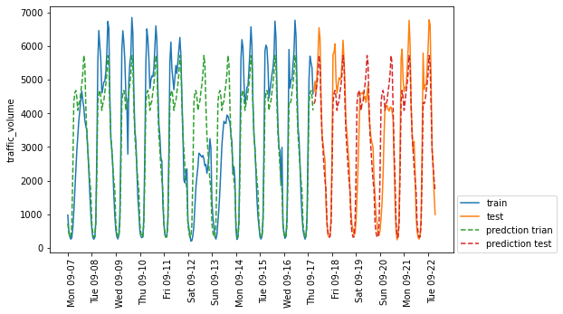

```python
print('LinearRegression')
fl_5 = pd.DataFrame(features_set_Cyc,  columns = features_L_5)
eval_on_features(fl_5,target_set,LinearRegression())
print('RandomForestRegressor')
fr_5 = pd.DataFrame(features_set_Cyc, columns = features_R_5)
eval_on_features(fr_5,target_set,regressor)
```

Same as above

```python
# Find the best seven features
features_L_7 = Feature_select(7,features_set_Cyc,target_set,LinearRegression())
features_L_7
```

```
['snow_1h',
 'clouds_all',
 'month_sin',
 'month_cos',
 'day_sin',
 'hour_sin',
 'hour_cos']
```

```python
# Find the best seven features
features_R_7 =Feature_select(7,features_set_Cyc,target_set,regressor)
features_R_7
```

```
['snow_1h',
 'temp',
 'month_sin',
 'month_cos',
 'day_sin',
 'hour_sin',
 'hour_cos']
```

```
LinearRegression
Test-set R^2:0.72
```

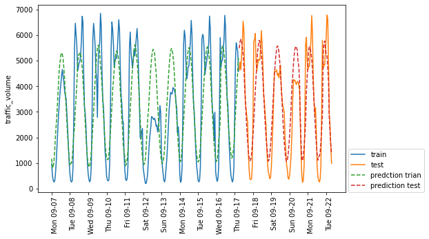

```
RandomForestRegressor
Test-set R^2:0.86
```

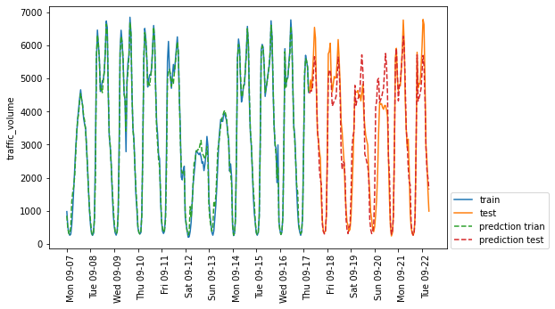

```python
print('LinearRegression')
fl_7 = pd.DataFrame(features_set_Cyc, columns = features_L_7)
eval_on_features(fl_7,target_set,LinearRegression())
print('RandomForestRegressor')
fr_7 = pd.DataFrame(features_set_Cyc,  columns = features_R_7)
eval_on_features( fr_7 , target_set, regressor)
```

The linear regression model scores were consistent. The random forest model scores are slightly improved.

For the linear regression model, the effective subsets of the features for this prediction task can be the three ['snow_1h', 'hour_sin,' 'hour_cos'], which obtain the highest scores and do not change when the number of features is raised to 7, which also enables the dimensionality reduction of the features.

Decrease the number of selected features, the relevance and classification ability will decrease accordingly; increase the number of selected features, both will also increase. The algorithm is stable only when the features in the dataset are balanced to a certain extent. So the critical problem is choosing the optimal m (or range), the only parameter of the random forest.

Therefore, the best score in the above test is when the number of features is 7. ['snow_1h','temp','month_sin','month_cos','day_sin','hour_sin','hour_cos']